# Machine Learning for Optimal Stopping Problems with mlOSP

Mike Ludkovski

April 16, 2018

## Getting Started with mlOSP

Load the necessary libraries (there are quite a few since we try many different regression methods)!

```r
library(ks)
library(fields) # for plotting purposes, use quilt.plot in 2D
library(seqOSP)
library(DiceKriging)
library(tgp)  # use lhs from there
library(randtoolbox)  # use sobol and halton QMC sequences
library(randomForest)
library(earth)
library(hetGP)
library(kernlab)
```

The seqOSP library has several principal schemes for constructing the emulators that describe the estimated stopping rule. The emulators are indexed by the underlying type of *design* which most affects the implementation. We have:

- osp.prob.design – this is the original Longstaff Schwartz scheme that generates forward trajectories that are then re-used as the design sites. In our notation, this is a pure probabilistic design, without any replication. It is married to a variety of regression methods, both parametric and nonparametric.
- osp.fixed.design – the generic RMC scheme with a pre-specified/fixed (in the sense of not sequential) design. In particular the design can be replicated using *km.batch* parameter. This approach nests the osp.prob.design when km.batch=1 and the input.domain is fully specified.
- osp.probDesign.piecewisebw – this is the Bouchard Warin implementation of RMC that utilizes a hierarchical (piecewise) linear model based on an equi-probable partition of the forward trajectory sites. Since we have a ``quick-and-dirty’’ recursive construction of the sub-domains, the fits from this function *cannot* be fed into a forward simulator. However, the function directly accepts a collection of test trajectories that are evaluated in parallel with the backward DP iteration.
- mc.put.adaptree – sequential RMC with *dynaTree* emulators
- osp.seq.design — sequential RMC with GP (ie Stochastic Kriging) emulators that are used to construct sequential design acquisition functions via the posterior emulator variance

### 1D Example

We start with a simple 1-D Bermudan Put. The underlying dynamics are given by Geometric Brownian Motion
$$dX_t = rX_t dt + \sigma X_t dW_t, \qquad X_0 = x_0$$
In the model specification below we have $r=0.06, T=1, \sigma=0.2$ and the option payoff is a Put $(K-X_t)_+$ with $K=40$. The exercise is possible 25 times, i.e $\Delta t = 0.04$.

We hand-build a few designs that cover in-the-money region $[25,40]$ using QMC sequences. As a start we use a Gaussian Process emulator with a replicated design. The replications are treated using the SK method (Ankenman et al 2012), pre-averaging the replicated outputs before training the GP. The GP has a constant prior mean, learned via the Universal Kriging equations (Ginsbourger et al 2013)

```r
# a few prespecified designs
grid1 <- c(30, 33:39)
grid2 <- c(28, 30, seq(32.5, 39, by=0.5))
grid3 <- sort(15*sobol(15)+25)
grid4 <- sort(15*sobol(200)+25)

# specify the simulation model, the payoff, and the emulator setup
model1 <- c(final.runs=0, K=40,x0=40,sigma=0.2,r=0.06,div=0,T=1,dt=0.04,dim=1,sim.func=sim.gbm,
 lhs.rect=c(25,40),init.size=15,km.cov=4,km.var=1,cand.len=1000,look.ahead=1)

put1d.model <- model1
put1d.model$km.batch <- 200
put1d.model$pilot.nsims = 0
put1d.model$covfamily="matern5_2"
put1d.model$N <- 500
option.payoff <- put.payoff

# use the DiceKriging Gaussian Process emulator with fixed hyperparameters specified in
# km.cov, km.var. The default kernel is Matern-5/2
km.fit <- osp.fixed.design(put1d.model,input.domain=grid3, method="km")
```

Now we visualize the results from one time-step. To do so, we first predict the timing value based on a fitted emulator (at $t=10\Delta t$ step) over a collection of points. We then plot the point estimate of $T(t,x)$ and the corresponding credible interval (which is organically provided by the GP emulator).

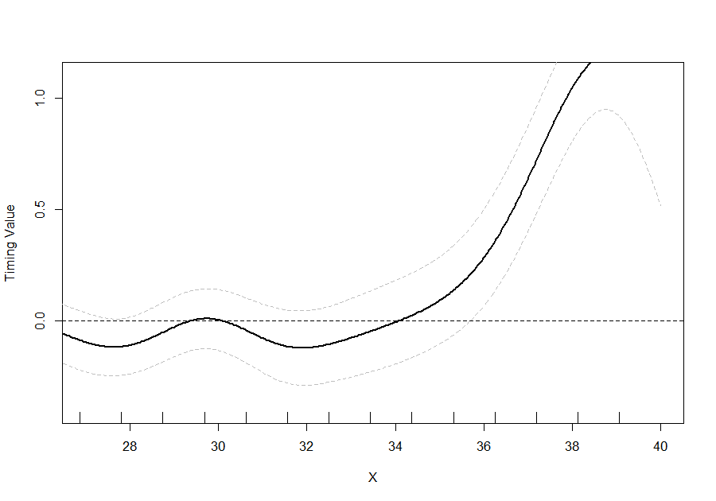

```r
check.x <- seq(24, 40, len=500)   # predictive sites
myCol <- "grey"
km.pred <- predict(km.fit$fit[[10]],data.frame(x=check.x), type="UK")  # syntax specific to km
plot(check.x, km.pred$mean, lwd=2, type="l", xlim=c(27,40), ylim=c(-0.4,1.1), xlab='X', ylab='Timing Value')
lines(check.x, km.pred$lower95, lty=2,col=myCol)  # 95% CI band, see documentation of predict.km
lines(check.x, km.pred$upper95, lty=2,col=myCol)
abline(h=0,lty=2)
rug(grid3, quiet=TRUE)
```

### 2D Average Put example

The two assets are assumed to be uncorrelated and with identical dynamics, thus the whole metamodel should be symmetric in $X_1,X_2$.

```r
al.params.km <- list(adaptive.grid.loop=100,look.ahead=1,init.size=100,final.runs=0,al.heuristic='sur',cand.len=1000,
km.batch=100,km.var=4,km.cov=c(6,6),km.upper=c(10,10))
lsmc.params <- list(mars.pen=1.5, mars.len=6,mars.thresh=1e-8,nChildren=5,rf.ntree=200,rf.nodesize=40,rf.maxnode=100)

model2d <- c(al.params.km,
             list(K=40,x0=rep(40,2),sigma=rep(0.2,2),r=0.06,div=0,T=1,dt=0.04,dim=2,sim.func=sim.gbm))
```

Test with a regular OLS regression against polynomial bases: a total of N=15000 training paths

```r
bas22 <- function(x) return(cbind(x[,1],x[,1]^2,x[,2],x[,2]^2,x[,1]*x[,2]))
model2d$bases <- bas22

prob.lm <- osp.prob.design(30000,model2d,method="lm",subset=1:15000)
```

```
## [1] "in-sample v_0 1.491033; and out-of-sample: 1.470553"
```

Repeat with GP: design of 150 sites replicated with 100 each. Uses the Gaussian squared-exponential kernel.

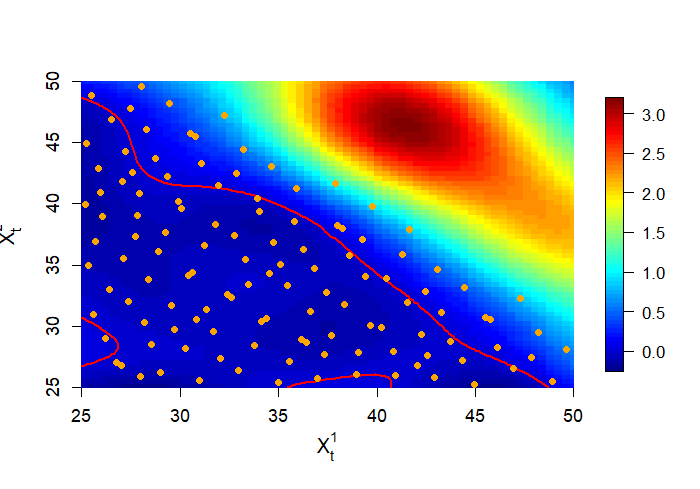

```r
lhs.rect <- matrix(0, nrow=2, ncol=2)
lhs.rect[1,] <- c(25,55)  # atm is x1+x2 < 80
lhs.rect[2,] <- c(25,55)
model2d$lhs.rect <- lhs.rect
model2d$pilot.nsims <- 0
model2d$N <- 150
model2d$covfamily <- "gauss"

sob150 <- sobol(276, d=2)
sob150 <- sob150[ which( sob150[,1] + sob150[,2] <= 1) ,]  # a lot are on the diagonal
sob150 <- 25+30*sob150

sob.km <- osp.fixed.design(model2d,input.domain=sob150, method="km")
require(fields)
plt.2d.surf( sob.km$fit[[15]], x=seq(25,50, len=101), y=seq(25,50,len=101), ub=10)
```

The above plot visualizes the stopping boundary (red contour) and the fitted timing value (the stopping region is the level set where the timing value is negative). We also display the underlying Sobol QMC design of size 150.

To do a proper comparison between the fits we create a single out-of-sample database and run both rules on it

```r
NN <- 16000
MM <- 25
set.seed(101)
mygr <- list()
mygr[[1]] <- model2d$sim.func( matrix(rep(model2d$x0, NN), nrow=NN, byrow=T), model2d, model2d$dt)
for (i in 2:(MM+1))
   mygr[[i]] <- model2d$sim.func( mygr[[i-1]], model2d, model2d$dt)
# sanity check: European option value
print(mean( exp(-model2d$r*model2d$T)*option.payoff(K=40,mygr[[MM]])))
```

```
## [1] 1.224074
```

```r
oos.lm <- forward.sim.policy( mygr, MM, prob.lm$fit, model2d)
oos.km <- forward.sim.policy( mygr, MM, sob.km$fit,  model2d)
print( c(mean(oos.lm$payoff), mean(oos.km$payoff)) )
```

```
## [1] 1.423687 1.431491
```

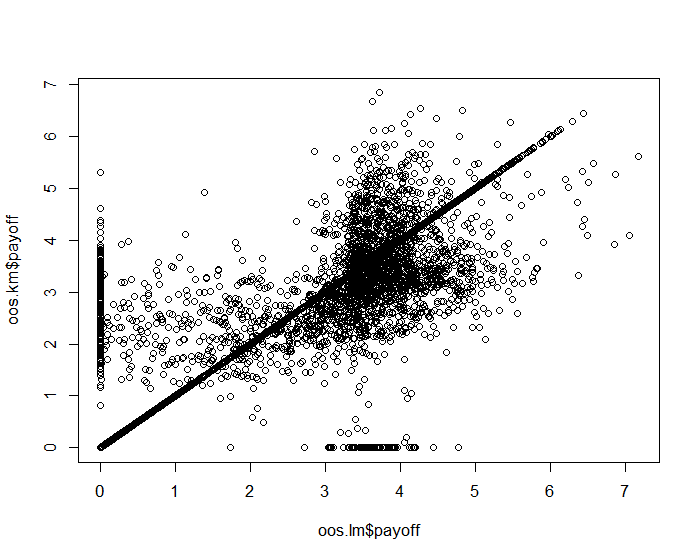

```r
plot(oos.lm$payoff, oos.km$payoff)
```

## Different types of designs

The first function is osp.prob.design. This is classical RMC that builds a design using forward simulation of state trajectories. Its main input is the *method* which can take a large range of regression methods. Specifics of each regression are controlled through specifying *required* respective model parameters.

First we consider a 1D example with **smooth.spline**. Note the syntax: we use a total of 30000 trajectories, of which the first 10000 are reserved for testing, and the last 20000 is the training set. We then also run a **randomForest**.

```r
put1d.model$nk=20  # number of knots for the smoothing spline
spl.eml.1dput <- osp.prob.design(30000,put1d.model,subset=1:10000,method="spline")
```

```
## [1] "in-sample v_0 2.307815; and out-of-sample: 2.326382"
```

```r
put1d.model$rf.ntree = 200  # random forest parameters
put1d.model$rf.maxnode=100
rf.eml.1dput <- osp.prob.design(30000,put1d.model,subset=1:10000,method="randomforest")
```

```
## [1] "in-sample v_0 2.442872; and out-of-sample: 2.270105"
```

As a a last example, We try **MARS** (multivariate adaptive regression splines) from the earth package. We set the degree to be 2, so that bases consist of linear/quadratic hinge functions.

```r
put1d.model$earth.deg = 2;  # earth parameters
put1d.model$earth.nk = 100;
put1d.model$earth.thresh = 1e-8
mars.eml.1dput <- osp.prob.design(30000,put1d.model,subset=1:10000,method="earth")
```

```
## [1] "in-sample v_0 2.301745; and out-of-sample: 2.229798"
```

## Space-filling Batched designs

The second function, which is the workhorse of seqOSP, is *osp.fixed.design* . It has three key parameters: input.domain which controls the construction of the design, km.batch that controls the replication amount and type which controls the regression method. Because the design is now user-specified, its size can vary step-by-step. The package also allows to vary the replication amounts.

We proceed to an overview of different ways to build a space-filling design. The main issue is how to generate the bounding hyper-rectangle. The package provides several ways to do so.

The first example utilizes a user-defined design that is used as-is. Below we use the sob150 design that places 150 design sites in a trianglular input domain. This is coupled with 100 replications/site for a total of 15000 simulation budget.

The *plt.2d.surf* function provides a way to visualize the emulator at a single time-step, showing both the timing value and the stopping boundary (which is the zero-contour of the latter). It also shows the respective design.

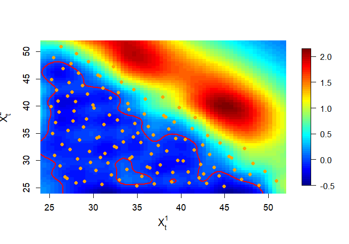

```r
sob150 <- sobol(276, d=2)
sob150 <- sob150[ which( sob150[,1] + sob150[,2] <= 1) ,]  # a lot are on the diagonal
sob150 <- 25+30*sob150

model2d$km.batch <- 100
model2d$pilot.nsims = 0
model2d$covfamily="matern5_2"
model2d$N = 500   # size of unique design sites; effective size is smaller as only in-the-money sites are kept

put2d.sobol.km <- osp.fixed.design(model2d,input.dom=sob150, method="km")
plt.2d.surf(put2d.sobol.km$fit[[12]], x=seq(24,52,len=101),y=seq(24,52,len=101),ub=10)
```

Secondly, we use an adaptive LHS design using some pilot simulations. Here input.dom=0.02 makes the LHS space-fill a box between the 2nd and 98th percentiles of the pilot trajectories at each time step. This organically expands the input domain as time passes.

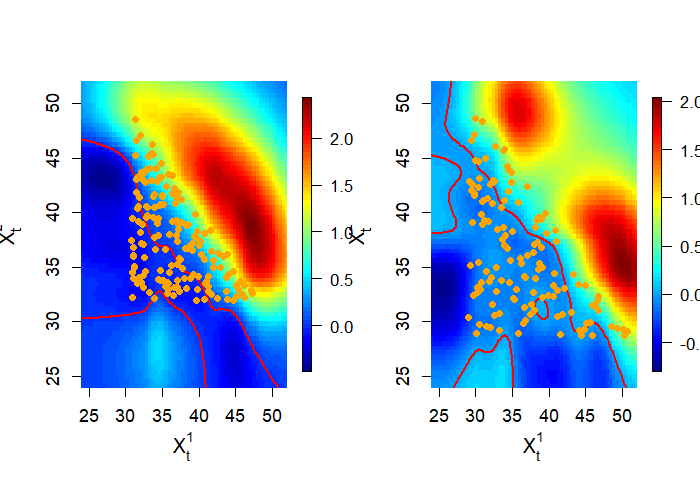

```r
model2d$pilot.nsims <- 1000
model2d$N = 500   # size of unique design sites; effective size is smaller as only in-the-money sites are kept
model2d$qmc.method <- NULL
put2d.lhsAdaptive.km <- osp.fixed.design(model2d,input.dom=0.02, method="km")
par(mfrow=c(1,2))
plt.2d.surf(put2d.lhsAdaptive.km$fit[[10]],x=seq(24,52,len=101),y=seq(24,52,len=101))
plt.2d.surf(put2d.lhsAdaptive.km$fit[[20]],x=seq(24,52,len=101),y=seq(24,52,len=101))
```

If we set input.dom=-1 then the full range of the pilot scenarios is used. Here we space-fill using a halton sequence. In addition, we also train the km model hyperparameters, which is the Stochastic Kriging metamodel. Here for variety sake we pick a Gaussian kernel

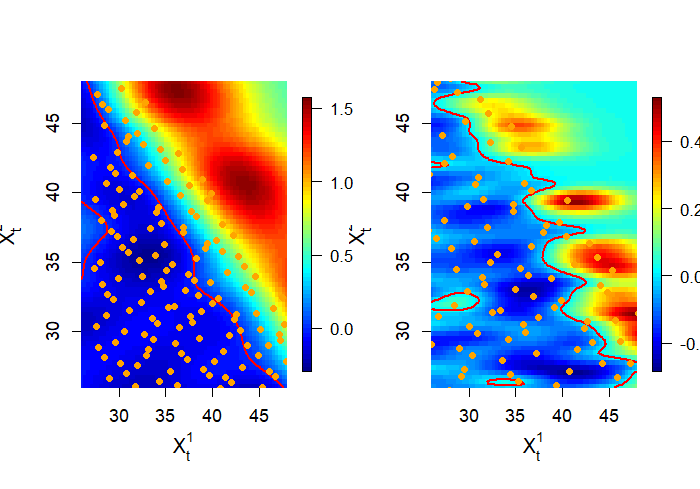

```r
model2d$pilot.nsims <- 1000
model2d$km.upper <- 20
model2d$N = 500   # size of unique design sites; effective size is smaller as only in-the-money sites are kept
model2d$qmc.method <- randtoolbox::halton
model2d$covfamily <- "gauss"
put2d.haltonRange.trainkm <- osp.fixed.design(model2d,input.dom=-1, method="trainkm")
par(mfrow=c(1,2))
plt.2d.surf(put2d.haltonRange.trainkm$fit[[10]],x=seq(26,48,len=101),y=seq(26,48,len=101))
plt.2d.surf(put2d.haltonRange.trainkm$fit[[20]],x=seq(26,48,len=101),y=seq(26,48,len=101))
```

```r
coef(put2d.haltonRange.trainkm$fit[[15]])
```

```
## $trend
## [1] 0.1625656
##
## $range
## [1] 3.605977 1.163375
##
## $shape
## numeric(0)
##
## $sd2
## [1] 0.073349
##
## $nugget
## numeric(0)
```

### Heteroskedastic GP emulator

Try now with hetGP and smaller replication counts

```r
model2d$pilot.nsims <- 1000
model2d$km.upper <- 20
model2d$km.batch <- 25
model2d$covfamily <- "Matern5_2"  # note that hetGP has a slightly different naming convention for kernels
model2d$N = 1000   # size of unique design sites; effective size is smaller as only in-the-money sites are kept
model2d$qmc.method <- randtoolbox::halton
put2d.haltonAdaptive.hetgp <- osp.fixed.design(model2d,input.dom=0.02, method="hetgp")
```

[output not shown]

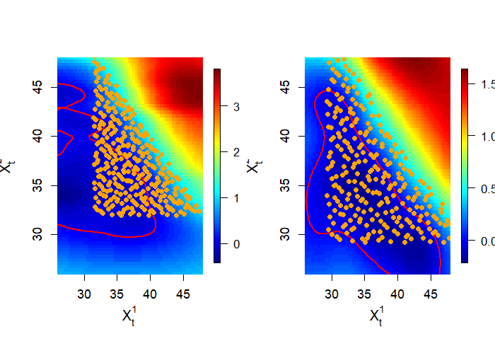

```r
par(mfrow=c(1,2))
plt.2d.surf(put2d.haltonAdaptive.hetgp$fit[[10]],x=seq(26,48,len=101),y=seq(26,48,len=101))
plt.2d.surf(put2d.haltonAdaptive.hetgp$fit[[20]],x=seq(26,48,len=101),y=seq(26,48,len=101))
```

```r
summary(put2d.haltonAdaptive.hetgp$fit[[15]])
```

```
## N =  7375  n =  295  d =  2
## Matern5_2  covariance lengthscale values of the main process:  11.61464 4.605157
## Variance/scale hyperparameter:  3.407988
## Summary of Lambda values:
##    Min. 1st Qu.  Median    Mean 3rd Qu.    Max.
##  0.2845  0.4249  0.5086  0.4827  0.5558  0.6073
## Estimated constant trend value:  0.7054976
## Matern5_2  covariance lengthscale values of the log-noise process:  11.61464 4.605157
## Nugget of the log-noise process:  1e-06
## Estimated constant trend value of the log-noise process:  -0.7416301
## MLE optimization:
##  Log-likelihood =  -10374.86 ; Nb of evaluations (obj, gradient) by L-BFGS-B:  146 146 ; message:  NEW_X
```

We can also use a probabilistic design based on the pilot trajectories. Note that this still embeds the replication aspect. To showcase the flexibility, here we make the design size change over t, using larger design for latter steps where the input domain is bigger

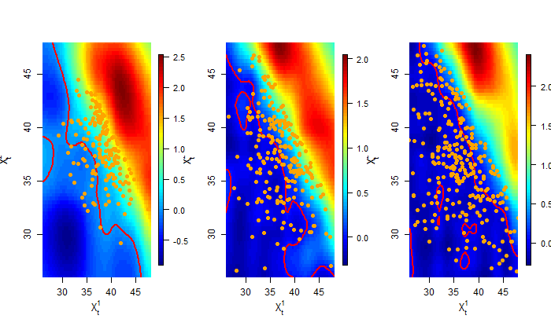

```r
option.payoff <- put.payoff
model2d$pilot.nsims <- 1000
model2d$km.batch <- 100
model2d$covfamily <- "matern5_2"
model2d$N <- c(rep(400,10), rep(600,10), rep(800,5))   # time-varying design size (sub-sampled from the pilot trajectories)
put2d.probRep.km <- osp.fixed.design(model2d,input.dom=NULL, method="km")
par(mfrow=c(1,3))
plt.2d.surf(put2d.probRep.km$fit[[6]],x=seq(26,48,len=101),y=seq(26,48,len=101))
plt.2d.surf(put2d.probRep.km$fit[[14]],x=seq(26,48,len=101),y=seq(26,48,len=101))
plt.2d.surf(put2d.probRep.km$fit[[22]],x=seq(26,48,len=101),y=seq(26,48,len=101))
```

After having built all these models we can do horse racing on a fixed out-of-sample set of scenarios. We use 40000 trajectories with a different initial condition and compute the payoffs from 4 different GP models.

```r
NN <- 40000
MM <- 25
set.seed(102)
test.2d <- list()
# use a different starting point
test.2d[[1]] <- model2d$sim.func( matrix(rep(c(41,40), NN), nrow=NN, byrow=T), model2d, model2d$dt)
for (i in 2:(MM+1))
   test.2d[[i]] <- model2d$sim.func( test.2d[[i-1]], model2d, model2d$dt)
# sanity check: European option value
print(mean( exp(-model2d$r*model2d$T)*option.payoff(K=40,test.2d[[MM]])))
```

```
## [1] 1.066452
```

```r
oos.1 <- forward.sim.policy( test.2d, MM, put2d.probRep.km$fit, model2d)
oos.2 <- forward.sim.policy( test.2d, MM, put2d.haltonRange.trainkm$fit,  model2d)
oos.3 <- forward.sim.policy( test.2d, MM, put2d.haltonAdaptive.hetgp$fit,  model2d)
oos.4 <- forward.sim.policy( test.2d, MM, put2d.lhsAdaptive.km$fit,  model2d)
print( c(mean(oos.1$payoff), mean(oos.2$payoff), mean(oos.3$payoff), mean(oos.4$payoff)) )
```

```
## [1] 1.256810 1.232206 1.256790 1.252350
```

## 3D Max Call Example

The following example is from Broadie and Glasserman 1997 paper. The true answer is about 11.25 under continuous exercise optionality. Here we follow the Andersen Broadie article in taking a crude $\Delta t = 1/3$ dicretization with just 9 exercise dates.

```r
# 3D MaxCall
call3d.params <- list(adaptive.grid.loop=250,look.ahead=1,init.size=200,final.runs=0,al.heuristic='sur',cand.len=1000,
    km.batch=80,km.var=20,km.cov=c(12.5,12.5,12.5),km.upper=c(20,20,20))

# Also in Andersen Broadie (MS'04), Table 2 p. 1230
modelBrGl3d <- c(call3d.params, nChildren=5, rf.ntree=200, list(K=100,r=0.05,div=0.1, sigma=rep(0.2,3),T=3, dt=1/3,
  x0=rep(90,3),dim=3, sim.func=sim.gbm),N=1000,pilot.nsims=100,covfamily="Matern5_2")
option.payoff <- maxCall

set.seed(44)
NN <- 10000
MM <- 9
test.3d <- list()
test.3d[[1]] <- sim.gbm( matrix(rep(modelBrGl3d$x0, NN), nrow=NN, byrow=T), modelBrGl3d)
for (i in 2:MM)
   test.3d[[i]] <- sim.gbm( test.3d[[i-1]], modelBrGl3d)
mean( exp(-modelBrGl3d$r*modelBrGl3d$T)*option.payoff(K=100,test.3d[[MM]]))
```

```
## [1] 9.622368
```

Use RVM kernel regression. Total design size is $20000 = 800 \cdot 25$.

```r
modelBrGl3d$N <- 800
modelBrGl3d$km.batch <- 25
lhs.rect <- matrix(0, nrow=3, ncol=2)
lhs.rect[1,] <- lhs.rect[2,] <- lhs.rect[3,] <- c(50,150)

call3d.lhsFixed.rvm <- osp.fixed.design(modelBrGl3d,input.domain=lhs.rect, method="rvm")
```

[output not shown]

```r
oos.rvm <- forward.sim.policy( test.3d,MM,call3d.lhsFixed.rvm$fit,modelBrGl3d,compact=TRUE)
print(c(mean(oos.rvm$payoff), call3d.lhsFixed.rvm$nsims, as.numeric(call3d.lhsFixed.rvm$timeElapsed)))
```

```
## [1]     11.14401 377615.00000     53.75361
```

Running this again with the DiceKriging/km emulator based on Stochastic Kriging.

```r
modelBrGl3d$N <- 800
modelBrGl3d$km.batch <- 25
modelBrGl3d$covfamily <- "matern5_2"
set.seed(1)
km.stats.bg3 <- array(0, dim=c(5,4))
# do it 5 times to see the rough spread across macro-replications
for (j in 1:5) {
  #modelBrGl3d$init.size <- 80+4*(j-1)
  call3d.lhsFixed.km <- osp.fixed.design(modelBrGl3d,input.domain=lhs.rect, method="km")
  oos <- forward.sim.policy( test.3d,MM,call3d.lhsFixed.km$fit,modelBrGl3d,compact=TRUE)
  km.stats.bg3[j,1:3] <- c(mean(oos$payoff), call3d.lhsFixed.km$nsims, as.numeric(call3d.lhsFixed.km$timeElapsed))
  #oos <- forward.sim.policy( mygr.itm,MM,lhs.run$fit,modelBrGl3d,offset=1,compact=TRUE)
  #km.stats.bg3[j,4] <- mean(oos$payoff)
}
```

We then compare to a piecewise-linear LM. It runs in under 15 seconds even for $N=300000= 3 \cdot 10^5$ paths.

```r
bw.run <- osp.probDesign.piecewisebw(300000,modelBrGl3d,test=test.3d)  #get 10.9
```

```
## [1] "11.207294323959  and out-of-sample  11.048456551667"
```

We now run a global linear regression using polynomial bases

```r
# run probabilistic design with polynomial bases
bas2 <- function(x) return(cbind(x[,1],x[,1]^2,x[,2],x[,2]^2,x[,1]*x[,2],x[,3],x[,3]^2,x[,3]*x[,2],x[,1]*x[,3]))

bas3 <- function(x) return(cbind(x[,1],x[,1]^2,x[,2],x[,2]^2,x[,1]*x[,2],x[,3],x[,3]^2,x[,3]*x[,2],x[,1]*x[,3],
   x[,1]^3,x[,2]^3,x[,3]^3,x[,1]^2*x[,2],x[,1]^2*x[,3],x[,2]^2*x[,1],x[,2]^2*x[,3],x[,3]^2*x[,1],x[,3]^2*x[,2],x[,1]*x[,2]*x[,3] ))
modelBrGl3d$bases <- bas3

lm.stats.3dcall <- array(0, dim=c(25,3))
for (j in 1:25) {
  lm.run <- osp.prob.design(320000,modelBrGl3d,method="lm",subset=1:20000)
  oos.lm <- forward.sim.policy(test.3d, MM, lm.run$fit, modelBrGl3d)
  lm.stats.3dcall[j,] <- c(lm.run$p[1], mean(oos.lm$payoff),as.numeric(lm.run$timeElapsed))
}
```

```
## [1] "in-sample v_0 10.873430; and out-of-sample: 10.888187"
## [1] "in-sample v_0 10.916094; and out-of-sample: 10.907866"
## [1] "in-sample v_0 10.959664; and out-of-sample: 11.019577"
## [1] "in-sample v_0 10.885040; and out-of-sample: 10.788527"
## [1] "in-sample v_0 10.903541; and out-of-sample: 10.950513"
## [1] "in-sample v_0 10.924580; and out-of-sample: 10.804960"
## [1] "in-sample v_0 10.900916; and out-of-sample: 10.889436"
## [1] "in-sample v_0 10.920229; and out-of-sample: 11.158136"
## [1] "in-sample v_0 10.903710; and out-of-sample: 10.748512"
## [1] "in-sample v_0 10.967821; and out-of-sample: 10.862634"
## [1] "in-sample v_0 10.919345; and out-of-sample: 10.850618"
## [1] "in-sample v_0 10.982414; and out-of-sample: 10.867990"
## [1] "in-sample v_0 10.918602; and out-of-sample: 10.812922"
## [1] "in-sample v_0 10.927092; and out-of-sample: 10.983945"
## [1] "in-sample v_0 10.888804; and out-of-sample: 11.042583"
## [1] "in-sample v_0 10.929830; and out-of-sample: 11.125946"
## [1] "in-sample v_0 10.914773; and out-of-sample: 10.919757"
## [1] "in-sample v_0 10.900249; and out-of-sample: 10.883576"
## [1] "in-sample v_0 10.927964; and out-of-sample: 10.987638"
## [1] "in-sample v_0 10.834475; and out-of-sample: 10.789021"
## [1] "in-sample v_0 10.942573; and out-of-sample: 10.909333"
## [1] "in-sample v_0 10.986976; and out-of-sample: 10.761150"
## [1] "in-sample v_0 10.873406; and out-of-sample: 10.884089"
## [1] "in-sample v_0 10.952033; and out-of-sample: 10.815565"
## [1] "in-sample v_0 10.929434; and out-of-sample: 10.811322"
```

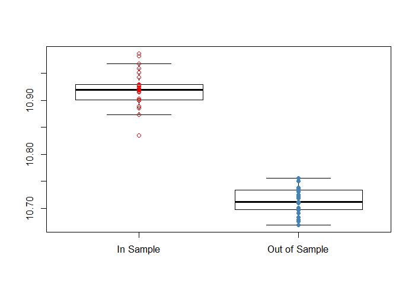

```r
# display the resulting sampling distribution of Call price
boxplot(cbind(lm.stats.3dcall[,1], lm.stats.3dcall[,2]), names=c('In Sample', 'Out of Sample'))
points(rep(1,25), lm.stats.3dcall[,1], col="red")  # in-sample ranges from 10.87 to 10.96
points(rep(2,25), lm.stats.3dcall[,2], col="steelblue", pch=19) # out of sample is lower
```

### Piecewise regression based on Bouchard-Warin

The osp.probDesign.piecewisebw function runs the Bouchard-Warin algorithm. This is a variant of the Longstaff-Schwartz scheme utilizing piecewise linear regressions. The regresion sub-domains are picked adaptively based on equi-probable partition of the generated trajectories. The partition uses model.nChildren bins in each dimension, so for the 2d problem below, taking nChildren=10 and $N=40000$ implies having 100 sub-domains with 400 trajectories in each. As can be seen, the role of nChildren is very crucial for algorithm performance.

The example below uses a 2D Stochastic Volatility model with a Put payoff from the Rambharat article.

```r
option.payoff <-sv.put
set.seed(1)
modelSV5 <- list(K=100,x0=c(90, log(0.35)),r=0.0225,div=0,sigma=1,
    T=50/252,dt=1/252,svAlpha=0.015,svEpsY=1,svVol=3,svRho=-0.03,svMean=2.95,
    eulerDt=1/2520, dim=2,sim.func=sim.expOU.sv,nChildren=10)
putPr <- osp.probDesign.piecewisebw(40000,modelSV5)
```

```
## [1] "16.5790742339776  and out-of-sample  15.1665524462384"
```

```r
 # get putPr$price= 16.81677
# now try again with a different number of partitions
modelSV5$nChildren <- 8
putPr2 <- osp.probDesign.piecewisebw(40000,modelSV5)
```

```
## [1] "16.5602474396111  and out-of-sample  16.8532495235528"
```

## Sequential Designs

The function *osp.seq.design* generates sequential designs using the SUR heuristic. It start with an initial design of size init.size and grows it until adaptive.grid.loop size. Below we start with 30 well-placed design sites, and add an additional 120, for a total of 150, with 20 replications each.

```r
require(laGP)  # needed for distance function
```

```r
sob30 <- sobol(55, d=2)
sob30 <- sob30[ which( sob30[,1] + sob30[,2] <= 1) ,]  # a lot are on the diagonal
sob30 <- 25+30*sob30

option.payoff <- put.payoff
model2d$adaptive.grid.loop <- 150  # final design size -- a total of 3000
model2d$km.batch <- 20
model2d$init.size <- 30   # initial design size
model2d$init.grid <- sob30
model2d$al.heuristic <- "sur"
model2d$covfamily <- "matern5_2"
put2d.sur.km <- osp.seq.design(model2d)
oos.km <- forward.sim.policy( mygr, MM, put2d.sur.km$fit, model2d)
print(mean(oos.km$payoff))
```

```
## [1] 0.9507421
```

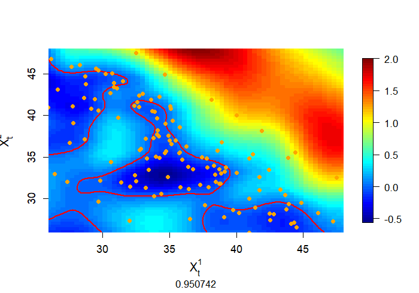

```r
plt.2d.surf(put2d.sur.km$fit[[18]],x=seq(26,48,len=101),y=seq(26,48,len=101),
            sub=sprintf("%4f",mean(oos.km$payoff)))
```

```r
model2d$covfamily <- "Matern5_2"
put2d.sur.hetgp <- osp.seq.design(model2d,method="hetgp")
```

[output not shown]

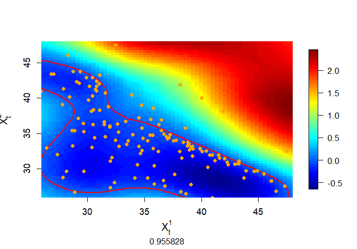

```r
oos.hetgp <- forward.sim.policy( mygr, MM, put2d.sur.hetgp$fit, model2d)
plt.2d.surf(put2d.sur.hetgp$fit[[10]],x=seq(26,48,len=101),y=seq(26,48,len=101),
            sub=sprintf("%4f",mean(oos.hetgp$payoff)))
```